[figure not shown]

WI-459

Door Cord LH

WIRING SYSTEM

73.Door Cord LH

A: LOCATION

Connector Connecting to

No. Pole Color Area No. Description

AB58 2 Y C-3 Front door impact sensor LH

AB62 2 Y D-2 R123 Rear wiring harness LH

D2

2 C-2 Front door speaker LH (standard model)

2 C-2 Front door speaker LH (premium model)

D3 6 GR C-3 Front power window motor LH

D5 10 C-2 Outer mirror assembly LH

D7 16 C-3 Power window main switch

D11 8 D-2 B101 Bulkhead wiring harness

D22 8 B-3 R10 Rear wiring harness LH

D23

2 C-4 Rear door speaker LH (standard model)

2 C-4 Rear door speaker LH (premium model)

D24 6 GR B-4 Rear power window motor LH

D25 8 B-4 Rear power window switch LH

D26 10 B-5 Rear door lock actuator LH

D66 6 B-3 Outer handle LH

D72 10 B-3 Front door lock actuator LH

D84 28 C-2 i101 Instrument panel wiring harness

D102 3 C-2 Power window main switch

D149 16 C-2 Remote control mirror switch

: White or natural color

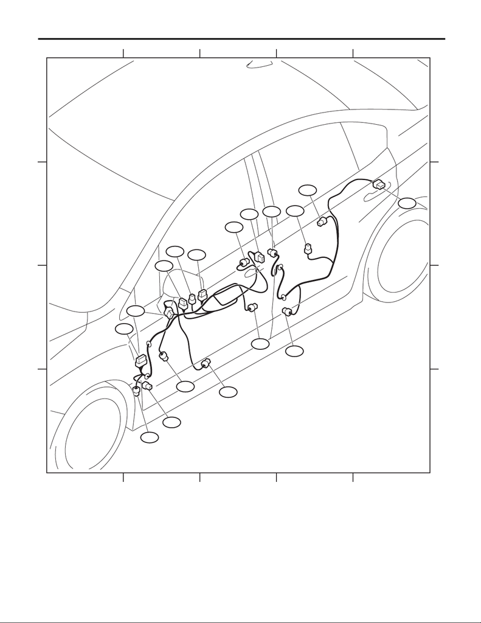

WI-460

Door Cord LH

WIRING SYSTEM

WI-44628

12345

12345

A

B

C

D

A

B

C

D

D5

D149

D11

AB62

D84

D2

D3

AB58

D23

D102

D7

D66

D72

D22

D25

D24

D26